# Métodos de remuestreo

# Instalen

```r
tinytex::install_tinytex()
install.packages("readr")
install.packages("stargazer")
```

# Introducción

- Herramienta indispensable para hacer estadística moderna.
- Extraer muestras en forma repetida de un conjunto de entrenamiento y ajustar para cada una de las muestras el modelo de interés.
- Se obtiene así *información adicional* con cada muestra acerca del modelo ajustado.
- Nos permite examinar en qué medida los resultados de nuestro ajuste difieren ante datos de entrenamiento distintos.

### ¿Por qué no se usaban antes?

- Es computacionalmente intenso.
- Dados los avances en poder de cómputo y en el desarrollo del cómputo en paralelo *ya no es tan restrictivo* el problema del cómputo.

# Métodos

Existen muchos métodos de remuestreo, por lo pronto examinaremos fundamnetalmente dos:

1. Validación cruzada: útil para estimar el error de prueba asociado a un método. Permite evaluar cuán bueno es y cuál es el nivel de flexibilidad apropiado.
   - *Evalución del modelo* (model assessment) es el proceso en el que se evalúa el desempeño de un modelo
   - *Selección de modelo* (model selection) es el proceso a través del cuál se selecciona el nivel de flexibilidad apropiado
2. Bootstrap: su uso más común es para proveer de una medida de la precisión de un parámetro estiamdo a partir de un método estadístico.

# Conjunto de prueba

$\text{Error de entrenamiento} \neq \text{Error de prueba}$

- El error de prueba el la media del error al utilizar un modelo ajustado en datos nuevos.
- Dado un conjunto de datos, se garantiza que el desempeño de un método será *bueno* si resulta en errores de prueba bajos.
- Puede calcularse fácilmente cuado *existe un conjunto de prueba*.
- No siempre es el caso.

# Error de entrenamiento

Es fácilmente calculable pero, ¿cuáles eran los problemas de medir el error en el conjunto de entrenamiento?

El error en entrenamiento tiende a:

- Ser muy diferente al error de prueba
- Tiende a subestimar el error de prueba

# Soluciones posibles

Dado que no siempre se tiene un conjunto de prueba, se puede estimar el error de prueba usando los datos a nuestra disposición.

- *Ajuste del error de entrenamiento*. Algunos métodos ajustan el error de entrenamiento para estimar el error de prueba.
- *Holding out*. Otra clase de métodos estima el error de prueba reteniendo un subconjunto de los datos al ajustar el modelo y aplica ese método a las observaciones retenidas.

=> Por ahora, nos concentramos en la segunda clase.

# Midiendo el error en un conjunto de prueba

1. Dividimos aleatoriamente nuestro conjunto de datos en dos: uno de entrenamiento y uno de prueba.
2. Ajustamos el modelo en los datos de entrenamiento.
3. Escogemos una medida del error.
4. Evaluamos el error en el conjunto de prueba.

# El ejemplo de los coches

```r
Auto <- read_csv("http://www-bcf.usc.edu/~gareth/ISL/Auto.csv") %>%
  mutate(horsepower = as.numeric(horsepower))

Auto <- mutate(Auto,
               horsepower.2 = horsepower * horsepower,
               horsepower.3 = horsepower.2 * horsepower)

mod.1 <- lm(data = Auto, mpg ~ horsepower)
mod.2 <- lm(data = Auto, mpg ~ horsepower + horsepower.2)
mod.3 <- lm(data = Auto, mpg ~ horsepower + horsepower.2 + horsepower.3)

stargazer(mod.1, mod.2, mod.3, type = "html", title = "Modelo lineal, cuadrático y cúbico.")
```

**Modelo lineal, cuadrático y cúbico.**

|  | *Dependent variable:* |  |  |
| --- | --- | --- | --- |
|  | mpg |  |  |
|  | (1) | (2) | (3) |
| horsepower | -0.158*** | -0.466*** | -0.569*** |
|  | (0.006) | (0.031) | (0.118) |
| horsepower.2 |  | 0.001*** | 0.002** |
|  |  | (0.0001) | (0.001) |
| horsepower.3 |  |  | -0.00000 |
|  |  |  | (0.00000) |
| Constant | 39.936*** | 56.900*** | 60.685*** |
|  | (0.717) | (1.800) | (4.563) |
| Observations | 392 | 392 | 392 |
| R<sup>2</sup> | 0.606 | 0.688 | 0.688 |
| Adjusted R<sup>2</sup> | 0.605 | 0.686 | 0.686 |
| Residual Std. Error | 4.906 (df = 390) | 4.374 (df = 389) | 4.375 (df = 388) |
| F Statistic | 599.718*** (df = 1; 390) | 428.018*** (df = 2; 389) | 285.481*** (df = 3; 388) |
| *Note:* | p<0.1; p<0.05; p<0.01 |  |  |

> ¿Cuál es el mejor modelo? ¿Significancia?

# Evaluamos con un conjunto de prueba

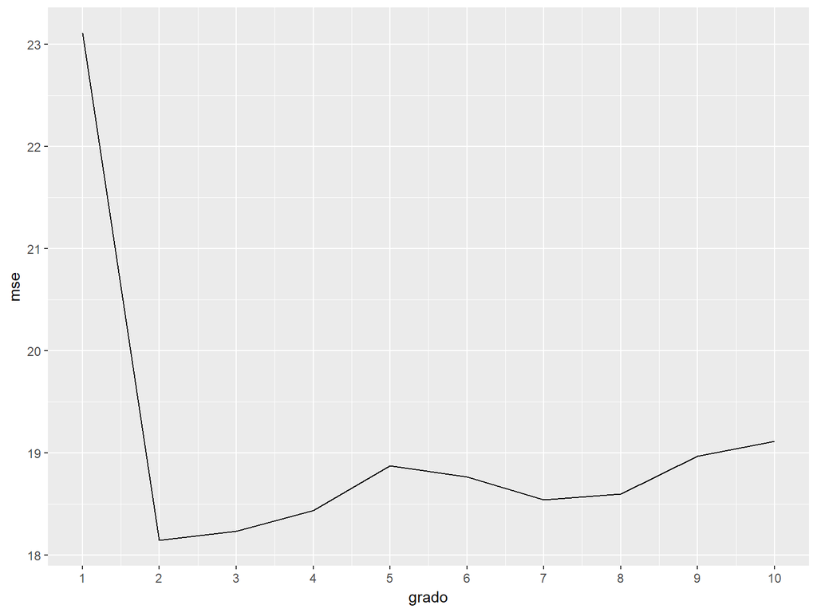

```r
Auto <- mutate(Auto,
               horsepower.4 = horsepower.3 * horsepower,
               horsepower.5 = horsepower.4 * horsepower,
               horsepower.6 = horsepower.5 * horsepower,
               horsepower.7 = horsepower.6 * horsepower,
               horsepower.8 = horsepower.7 * horsepower,
               horsepower.9 = horsepower.8 * horsepower,
               horsepower.10 = horsepower.9 * horsepower)
Auto <- na.exclude(Auto)

set.seed(2811)

indices <- sample(seq(nrow(Auto)), ceiling(nrow(Auto)/2))
entrena <- Auto[indices, ]
prueba <- Auto[-indices, ]

vars <- paste0("horsepower.", 2:10)
formulas.mods <- "mpg ~ horsepower"

modelos <- list("horsepower" = lm(data = entrena, as.formula(formulas.mods)))
for ( e in vars ) {
  formulas.mods <- paste0(formulas.mods, " + ", e)
  modelos[[e]] <- lm(data = entrena, as.formula(formulas.mods))
}

# mse en PRUEBA
mse <- function(modelo, datos.prueba) {
  datos.prueba$prediccion <- predict(modelo, newdata = datos.prueba)
  datos.prueba$residual <- datos.prueba$mpg - datos.prueba$prediccion
  mean(datos.prueba$residual^2)
}

graf <- tibble(grado = seq(10), mse = sapply(modelos, FUN = function(m){mse(m, prueba)}, simplify = T))
ggplot(graf, aes(x = grado, y = mse)) + geom_line() +
  scale_x_continuous(breaks = graf$grado)
```

# Ejercicio

1. Repite el ejercicio de los grados del polinomio pero generando aleatoriamente 10 conjuntos de prueba y entrenamiento *distintos*.
2. Grafícalo.

# Ejercicio - respuesta

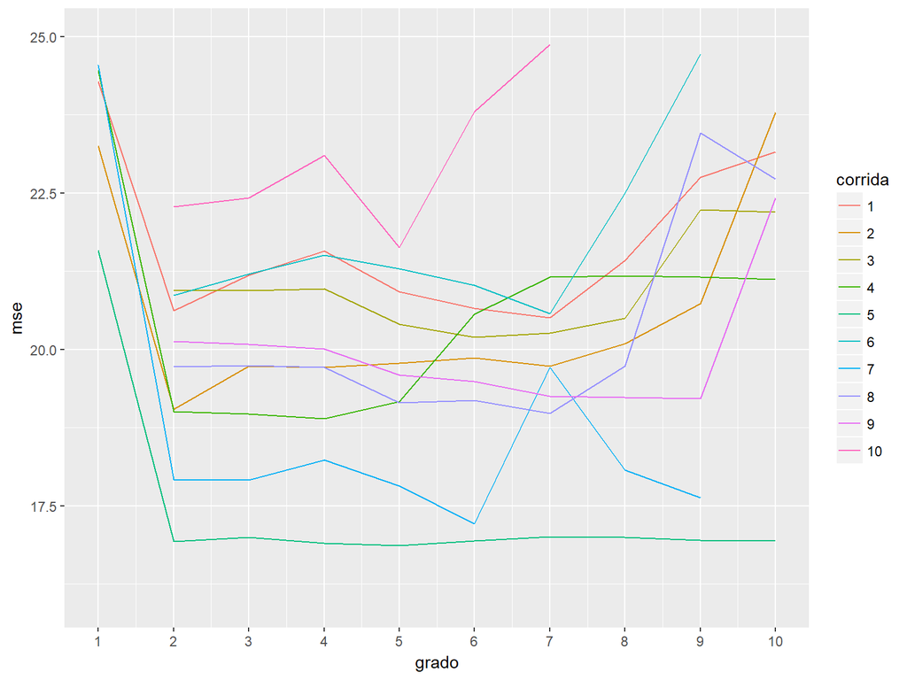

```r
mse <- function(modelo, datos.prueba) {
  datos.prueba$prediccion <- predict(modelo, newdata = datos.prueba)
  datos.prueba$residual <- datos.prueba$mpg - datos.prueba$prediccion
  mean(datos.prueba$residual^2)
}
una.corrida <- function(nombre = "") {
  indices <- sample(seq(nrow(Auto)), ceiling(nrow(Auto)/2))
  entrena <- Auto[indices, ]
  prueba <- Auto[-indices, ]

  vars <- paste0("horsepower.", 2:10)
  formulas.mods <- "mpg ~ horsepower"

  modelos <- list("horsepower" = lm(data = entrena, as.formula(formulas.mods)))
  for ( e in vars ) {
    formulas.mods <- paste0(formulas.mods, " + ", e)
    modelos[[e]] <- lm(data = entrena, as.formula(formulas.mods))
  }

  graf <- tibble(grado = seq(10), mse = sapply(modelos, FUN = function(m){mse(m, prueba)}, simplify = T))
  if (nombre != "") graf$corrida <- nombre
  graf
}

corridas <- lapply(seq(10), FUN = function(x){una.corrida(x)})
df.corr <- Reduce('rbind', corridas)

## 2 - graficalo
ggplot(df.corr %>% mutate(corrida = as.factor(corrida)), aes(x = grado, y = mse, group = corrida, color = corrida)) +
  geom_line() + ylim(16, 25) +
  scale_x_continuous(breaks = graf$grado)
```

# Problemas de usar un conjunto de prueba

Del ejercicio anterior podemos ver que:

- El estimador del error de prueba es muy variable pues depende de qué observaciones entraron en el conjunto de entrenamiento.
- Usamos únicamente un subconjunto de las observaciones a nuestra disposición. Los métodos estadísticos tienden a ser mejores con más observaciones y, por ende, sobreestimamos el error de prueba con respecto a si usamos todo el conjunto de datos.
- **Validación cruzada** busca minimizar estos dos problemas.

# Leave-one-out cross-validation (LOOCV)

1. Dividimos nuestro conjunto de datos en dos: uno de entrenamiento y uno de prueba. El segundo lo formamos de una única observación.
2. Ajustamos el modelo en los datos de entrenamiento ($n-1$ observaciones).
3. Predecimos $\hat{y_i}$ de la observación excluida.
4. Calculamos $MSE_i = (y_i - \hat{y_i})^2$
5. Lo repetimos para las n observaciones para obtener $MSE_1, ..., MSE_n$.
6. El estimador del $MSE_{prueba}$ por LOOCV es el promedio de estos n cálculos de error.
   $$CV_{(n)} = \frac{1}{n}\sum_{i=1}^n MSE_i$$

# LOOCV: ventajas y desventajas

- **Ventajas**
  - Tiene menos sesgo. LOOCV tiende a no sobreestimar el error de prueba tanto como cuando usamos un solo conjunto de prueba.
  - Realizarlo múltiples veces siempre da el mismo resultado pues la asignación en prueba y validación no es aleatoria.
- **Desventajas**
  - Dificil de implementar pues consume mucho poder de cómputo.
  - Si $n$ es grande, y cada modelo toma mucho tiempo en entrenar el problema se multiplica.

# LOOCV: Ejercicio

1. Aplica LOOVC a los datos de `Auto` en el caso cuadrático.
2. Calcula el estimador $CV_{(n)}$
3. Para el caso de regresión por mínimos cuadrados o regresión polinomial (**únicamente**), se cumple que:
   $$CV_{(n)} = \frac{1}{n}\sum_{i=1}^n (\frac{y_i - \hat{y_i}}{1-h_i})^2$$
   Calcula el estimador usando la fórmula.

# Respuesta - LOOCV

```r
# 1
Auto <- read_csv("http://www-bcf.usc.edu/~gareth/ISL/Auto.csv") %>%
  mutate(horsepower = as.numeric(horsepower))

Auto <- mutate(Auto,
               horsepower.2 = horsepower * horsepower) %>%
  na.exclude()

una.corrida <- function(i){
  mod <- lm(mpg ~ horsepower + horsepower^2, data = Auto[-i, ])
  prediccion <- predict(mod, newdata = Auto[i, ])
  residual.2 <- (Auto[i, ]$mpg - prediccion)^2
  residual.2
}

mses <- sapply(seq(nrow(Auto)), FUN = function(i){una.corrida(i)})

# 2
cv_n <- mean(mses)

# 3
mod <- lm(mpg ~ horsepower + horsepower^2, data = Auto)
Auto$hat <- hatvalues(mod)
Auto$prediccion <- predict(mod, newdata = Auto)
Auto$residual <-
Auto <- Auto %>%
  mutate(hat = hatvalues(mod)
         , prediccion = predict(mod, newdata = Auto)
         , residual = (mpg-prediccion)
         , aux = residual/(1-hat)
         , aux = aux^2)

sum(Auto$aux)/nrow(Auto)
```

```
## [1] 24.23151
```

```r
# comparamos
cv_n
```

```
## [1] 24.23151
```

$CV_{(n)} = \frac{1}{n}\sum_{i=1}^n (\frac{y_i - \hat{y_i}}{1-h_i})^2$

# k-fold cross-validation

1. Dividimos nuestro conjunto de datos en forma aleatoria en $k$ subconjuntos de más o menos el mismo tamaño.
2. Tratamos a cada uno de los $k$ subconjuntos como un conjunto de prueba en iteraciones independientes. Es decir, para cada subconjunto, ajustamos un modelo con el resto de los datos divididos en los $k-1$ grupos y usamos las observaciones en el grupo $k$ como prueba.
3. Repetimos el proceso $k$ veces (para cada grupo de observaciones).
4. Generamos $k$ estimadores del error de prueba $MSE_1, ..., MSE_k$.
5. El estimador del $MSE_{prueba}$ por validación cruzada es el promedio de estos $k$ cálculos de error.
   $$CV_{(k)} = \frac{1}{k}\sum_{i=1}^k MSE_i$$
   Nota como LOOCV es un caso particular de k-fold CV en donde $k = n$

# Validación cruzada: ventajas y desventajas

- **Ventajas**
  - Ventaja computacional sobre LOOVC
  - Método general que puede ser aplicado a casi cualquier método de aprendizaje estadístico.
- **Desventajas**
  - Hay variabilidad en el estimador del error de prueba debido a como se distribuyen las observaciones en los k-grupos. Esta variabilidad es menor que la que te da un estimador donde aleatoriamente divides el conjunto de datos en prueba y entrenamiento.
  - Hay sobre o subestimación del error de prueba mientras cambia la flexibilidad de los modelos utilizados.

# Validación cruzada: para qué sirve

- Se utiliza cuando nuestro objetivo es determinar cuán bueno podemos esperar que sea un método de aprendizaje específico para predecir nuevos datos. En este caso el valor del estimador del error es de interés.
- Se utiliza también cuando es de interés conocer el menor valor del error para contrastar entre distintos métodos posibles. En este caso, no interesa tanto el valor del estimador sino encontrar en dónde se encuentra el mínimo error, es decir, la flexibilidad del modelo.

# Trade-off entre sesgo y varianza

- LOOCV tiene ventajas sobre K-fold CV pues genera estimadores menos sesgados.
- K-fold tiene la ventaja que es menos intensivo computacionalmente.
- También tiene otra ventaja aún más importante: en la mayoría de los casos da estimadores más precisos del error de prueba. Esto es por el *trade-off* que existe entre sesgo y varianza.
- Típicamente, se usa $k=5$ o $k = 10$.

# Trade-off entre sesgo y varianza

- **Sesgo**
  - Cuando usamos un conjunto 50-50 de validación y entrenamiento, tenemos una sobreestimación del error de prueba: estamos usando menos observaciones (es como desperdiciar información y siempre a más info, menos sesgo)
  - LOOCV da estimadores más o menos insesgados del error de prueba pues usamos casi todas las observaciones que tenemos.
  - k-fold da un nivel de sesgo intermedio entre validación y LOOCV.

# Trade-off entre sesgo y varianza

- **Varianza**
  - LOOCV es un procedimiento con mayor varianza.
  - LOOCV genera n modelos que se entrenan con conjuntos de datos casi iguales.
  - EStamos promediando el resultado de n modelos cuyos resultados están altamente correlacionados.
  - En k-fold promediamos k resultados que están menos correlacionados pues hay menos intersección de las observaciones que se utilizan para entrenar cada modelo.
  - La media de cantidades altamente correlacionadas tiene mayor varianza que la media de cantidades con menor correlación.

# Validación cruzada en problemas de clasificación

- Para aplicarlo, simplemente cambiamos la medida del error.
- Para regresión, estabamos usando MSE. Ahora usamos, por ejemplo, el número de observaciones mal clasificadas.
- El estimador LOOCV toma la forma:
  $$CV_{(n)} = \frac{1}{n}\sum_{i=1}^n Error_i$$
  donde $Error_i = I(y_i \neq \hat{y_i})$. Se define de forma análoga el estimador por k-fold CV.